# Notebook 20 – Solutions

## Getting Started

Before running this notebook, select “Session > Restart R and Clear Output” in the menu above to start a new R session. This will clear any old data sets and give us a blank slate to start with.

After starting a new session, run the following code chunk to load the libraries and data that we will be working with today.

## Bird Observations in France

The data for this notebook consists of a subset of bird observations from France between 2010 and 2019. The data comes from https://doi.org/10.15468/dl.bwuax7. I have taken a random subsample that takes a random sample of 100k sightings from the 100 most common species of bird.

Below, is the main dataset, with one row per observation of a bird. It includes the time, location, and scientific name of the bird. I will add a geospatial attribute for you to the dataset as it will be needed in the questions below.

```r
source("../funs/funs.R")

birds <- read_csv("../data/french_birds.csv.bz2")
birds <- st_as_sf(birds, coords = c("lon", "lat"), crs = 4326, remove = FALSE)
birds
```

```
## Simple feature collection with 100000 features and 4 fields
## Geometry type: POINT
## Dimension:     XY
## Bounding box:  xmin: -5.1342 ymin: 41.43501 xmax: 9.55571 ymax: 51.0729
## Geodetic CRS:  WGS 84
## # A tibble: 100,000 × 5
##    date          lon   lat scientific_name                    geometry
##  * <date>      <dbl> <dbl> <chr>                           <POINT [°]>
##  1 2010-01-13  2.11   49.3 Corvus frugilegus Linn…  (2.10596 49.33126)
##  2 2010-01-13  1.32   43.6 Emberiza schoeniclus (…  (1.32246 43.64879)
##  3 2010-01-13 -3.39   47.7 Gallinago gallinago (L… (-3.39164 47.71596)
##  4 2010-01-13  6.39   44.5 Motacilla alba Linnaeu…  (6.39454 44.52672)
##  5 2010-01-13  2.37   49.9 Prunella modularis (Li…   (2.3745 49.87215)
##  6 2010-01-13  2.11   49.3 Pyrrhula pyrrhula (Lin…  (2.10596 49.33126)
##  7 2010-01-13  1.61   50.5 Turdus pilaris Linnaeu…  (1.60765 50.45283)
##  8 2010-01-13 -0.944  44.7 Vanellus vanellus (Lin… (-0.94404 44.71436)
##  9 2010-01-14  1.95   49.0 Carduelis chloris (Lin…   (1.94986 49.0017)
## 10 2010-01-14  6.82   47.7 Certhia brachydactyla …  (6.82303 47.74099)
## # ℹ 99,990 more rows
```

We also have a metadata table describing each of the bird species. You can join to the `birds` data using the key “scientific_name”. Most important for the questions questions are the columns `species_common` (a common name for this bird species) and `order_common` (a common name for a larger grouping of birds that this species is a part of).

```r
species <- read_csv("../data/french_bird_species.csv.bz2")
species
```

```
## # A tibble: 100 × 11
##    scientific_name    species_common order_common kingdom phylum class order
##    <chr>              <chr>          <chr>        <chr>   <chr>  <chr> <chr>
##  1 Accipiter nisus (… Eurasian spar… Hawk         Animal… Chord… Aves  Acci…
##  2 Acrocephalus scho… Sedge warbler  Sparrow      Animal… Chord… Aves  Pass…
##  3 Acrocephalus scir… Common reed w… Sparrow      Animal… Chord… Aves  Pass…
##  4 Aegithalos caudat… Long-tailed t… Sparrow      Animal… Chord… Aves  Pass…
##  5 Alauda arvensis L… Eurasian skyl… Sparrow      Animal… Chord… Aves  Pass…
##  6 Alcedo atthis (Li… Common kingfi… Kingfisher   Animal… Chord… Aves  Cora…
##  7 Anas crecca Linna… Eurasian teal  Waterfowl    Animal… Chord… Aves  Anse…
##  8 Anas platyrhyncho… Mallard        Waterfowl    Animal… Chord… Aves  Anse…
##  9 Anthus pratensis … Meadow pipit   Sparrow      Animal… Chord… Aves  Pass…
## 10 Anthus trivialis … Tree pipit     Sparrow      Animal… Chord… Aves  Pass…
## # ℹ 90 more rows
## # ℹ 4 more variables: family <chr>, genus <chr>, species <chr>, iucn <chr>
```

We also have a spatial polygon dataset describing the 96 French Départements (roughly the equivalent of a state/county). Below, I am taking a subset to only include those regions in France within Europe, which is the extent of the birds data from above.

```r
france <- read_sf("../data/france_departement.geojson")
france <- slice(france, 1:96)
france
```

```
## Simple feature collection with 96 features and 2 fields
## Geometry type: MULTIPOLYGON
## Dimension:     XY
## Bounding box:  xmin: -5.14026 ymin: 41.33363 xmax: 9.55996 ymax: 51.089
## Geodetic CRS:  WGS 84
## # A tibble: 96 × 3
##    departement departement_name                                     geometry
##    <chr>       <chr>                                      <MULTIPOLYGON [°]>
##  1 01          Ain                     (((4.78021 46.17668, 4.78024 46.1890…
##  2 02          Aisne                   (((3.17296 50.01131, 3.17382 50.0118…
##  3 03          Allier                  (((3.03207 46.79491, 3.03424 46.7908…
##  4 04          Alpes-de-Haute-Provence (((5.67604 44.19143, 5.67817 44.1905…
##  5 05          Hautes-Alpes            (((6.26057 45.12685, 6.26417 45.1264…
##  6 06          Alpes-Maritimes         (((7.06711 43.51365, 7.06665 43.5148…
##  7 07          Ardèche                 (((4.48313 45.23645, 4.4879 45.23218…
##  8 08          Ardennes                (((4.23316 49.95775, 4.2369 49.95858…
##  9 09          Ariège                  (((1.68842 43.27355, 1.69139 43.2717…
## 10 10          Aube                    (((3.41479 48.39027, 3.41555 48.3937…
## # ℹ 86 more rows
```

Finally, we also have a dataset describing the population of each departement.

```r
population <- read_csv("../data/france_departement_population.csv")
population <- slice(population, 1:96)
population
```

```
## # A tibble: 96 × 2
##    departement population
##    <chr>            <dbl>
##  1 01              643350
##  2 02              534490
##  3 03              337988
##  4 04              163915
##  5 05              141284
##  6 06             1083310
##  7 07              325712
##  8 08              273579
##  9 09              153153
## 10 10              310020
## # ℹ 86 more rows
```

## 1. Observations per day of the week [temporal]

For the first question, produce a bar plot with day of the week on the x-axis and a count of the number of bird sightings in our dataset on the y-axis. Use full names for the days of the week.

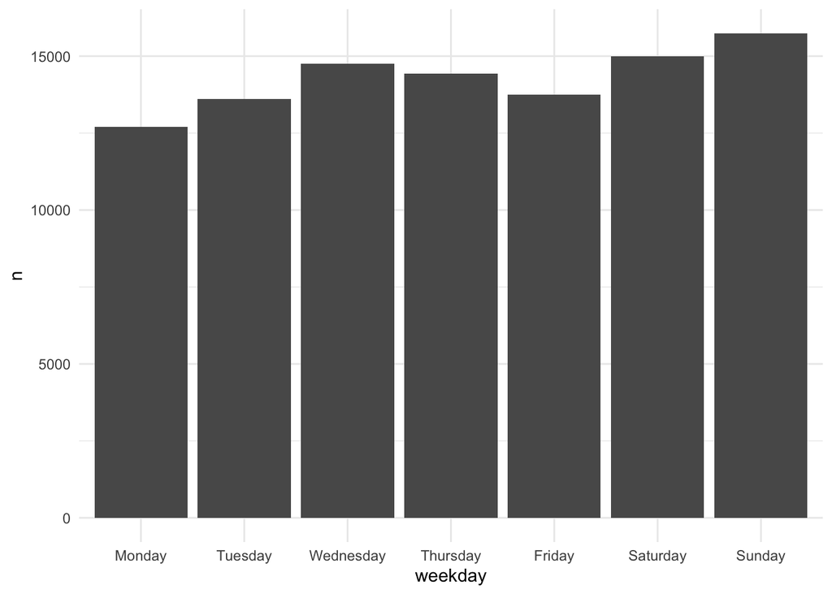

```r
# Question 01
birds |>
  mutate(weekday = wday(date, label = TRUE, abbr = FALSE)) |>
  group_by(weekday) |>
  summarize(n = n()) |>
  ggplot(aes(weekday, n)) +
    geom_col()
```

## 2. Observations over 2015 [temporal]

Create a scatterplot with one point for each day of the year in 2015. On the x-axis put the date and on the y-axis put the number of observations of birds found on that day in 2015. Have the x-axis use the abbreviated month names with breaks and minor breaks given once per month.

Hint: Use the formatting code “%b”.

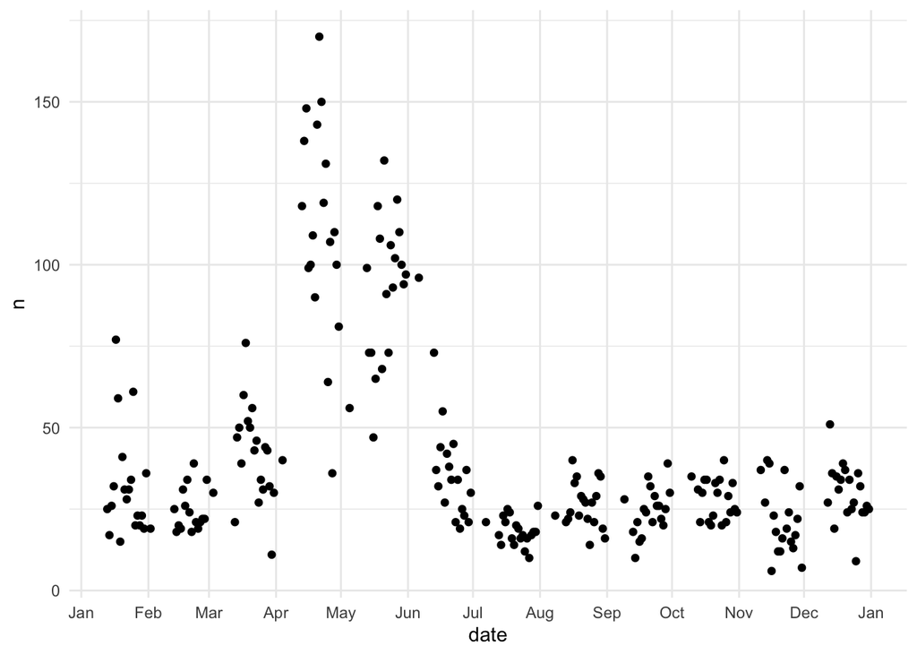

```r
# Question 02
birds |>
  filter(year(date) == 2015) |>
  group_by(date) |>
  summarize(n = n()) |>
  ggplot(aes(date, n)) +
    geom_point() +
    scale_x_date(
      date_breaks = "month",
      date_minor_breaks = "month",
      date_labels = "%b"
    )
```

## 3. Observations by order

Create a bar plot with common order names on the y-axis and a count of the number of birds across the whole dataset from each order. Arrange the y-axis categories in descending or ascending order (your choice).

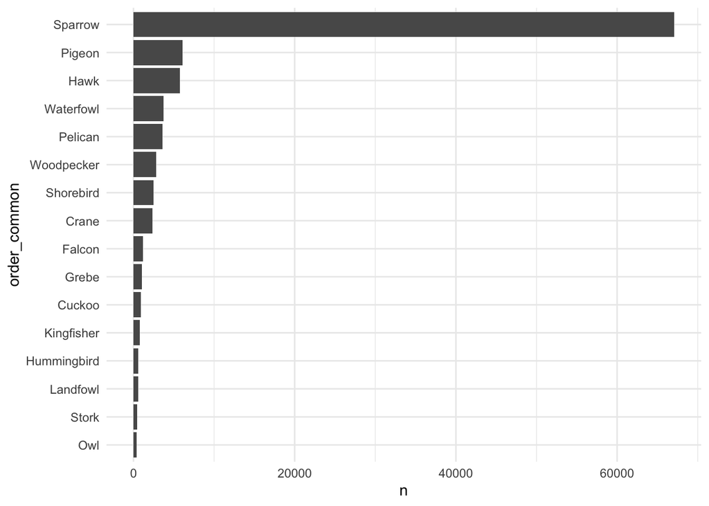

```r
# Question 03
birds |>
  inner_join(species, by = "scientific_name") |>
  group_by(order_common) |>
  summarize(n = n()) |>
  ungroup() |>
  arrange(n) |>
  mutate(order_common = fct_inorder(order_common)) |>
  ggplot(aes(n, order_common)) +
    geom_col()
```

## 4. Spatial distribution of observations [spatial] (easy)

For this question, plot the spatial locations of the `birds` data using the CRS projection 27561. Set the size of the points to 0.3 to make the plot easier to read.

Note: Feel free to change the figure height to make the plot look best on your screen.

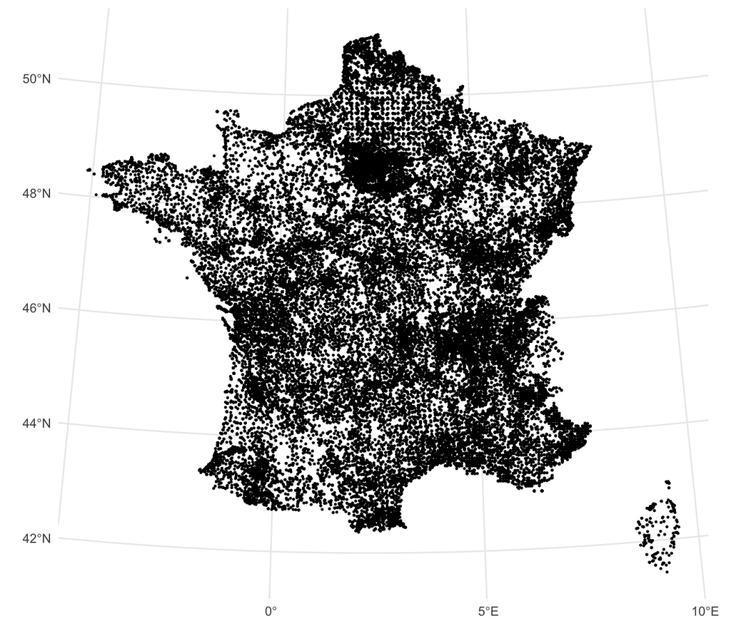

```r
# Question 04
birds |>
  st_transform(27561) |>
  ggplot() +
    geom_sf(size = 0.3)
```

## 5. Spatial distribution of observations [spatial] (easy)

For this question, plot the spatial dataset of French departements from the dataset `france`, coloring the points based on their population and using the CRS projection 27561. Use the following color scale in the plot:

scale_fill_distiller( trans = “log2”, palette = “Spectral”, guide = “legend”, n.breaks = 5 )

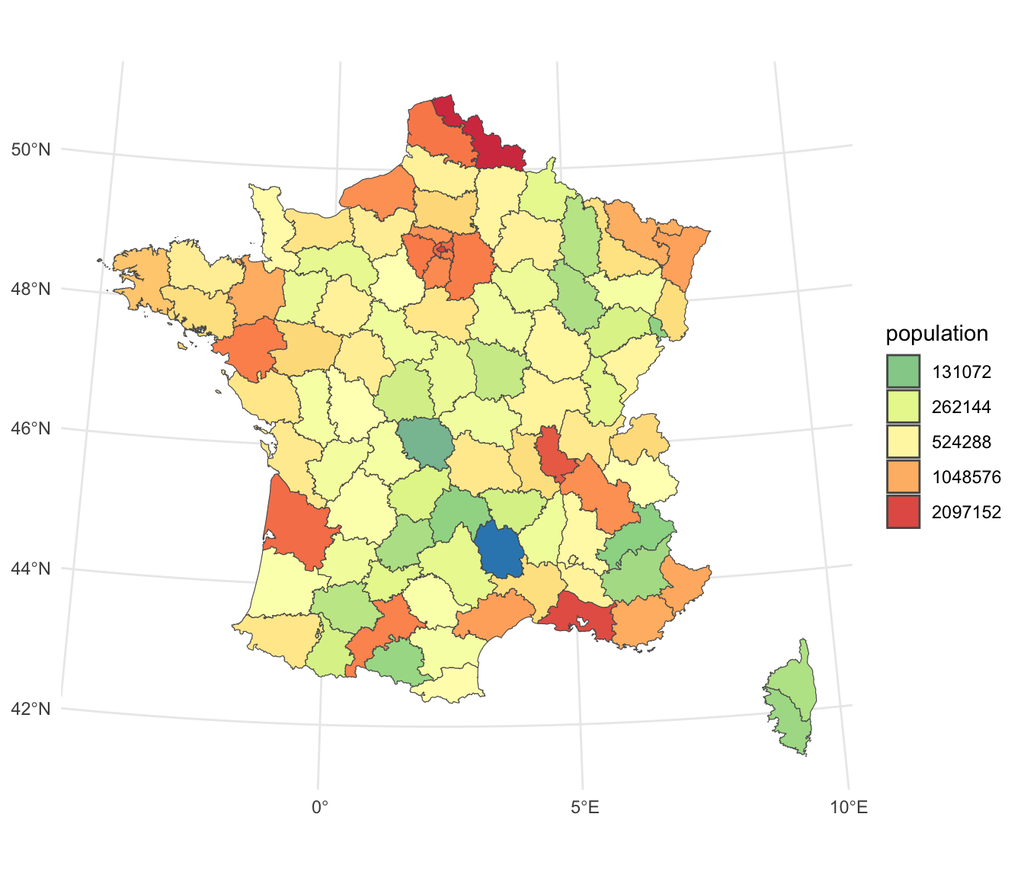

```r
# Question 05
france |>
  left_join(population, by = "departement") |>
  st_transform(27561) |>
  ggplot() +
    geom_sf(aes(fill = population), size = 0) +
    scale_fill_distiller(
      trans = "log2", palette = "Spectral", guide = "legend", n.breaks = 5
    )
```

## 6. Birds in Paris [spatial]

In this question, do a spatial join of `birds` into `france`. Then, for each bird species, compute the proportion of total sightings that occurred where `departement == "75"` (that’s the code for Paris). Order the results in descending order and display the common species name for each species to show those birds most commonly associated with Paris.

If your code is running very slow, note that you can (optionally) use `as_tibble()` after the spatial join to speed things up.

Hint: You should find that the most strongly associated bird with Paris is the “Rock dove”. It sounds beautiful, but if you do an image search online you’ll see that this is the nasty pigeon-type bird that have invaded large cities all over the world.

```r
# Question 06
birds |>
  spatial_join(france) |>
  as_tibble() |>
  left_join(species, by = "scientific_name") |>
  group_by(species_common) |>
  summarize(avg_paris = mean(departement == "75")) |>
  arrange(desc(avg_paris))
```

```
## # A tibble: 100 × 2
##    species_common         avg_paris
##    <chr>                      <dbl>
##  1 Rock dove                0.0502
##  2 House sparrow            0.00791
##  3 Short-toed treecreeper   0.00721
##  4 Black-headed gull        0.00673
##  5 Grey wagtail             0.00670
##  6 Carrion crow             0.00543
##  7 Eurasian sparrowhawk     0.00540
##  8 European greenfinch      0.00532
##  9 Eurasian blue tit        0.00496
## 10 Mallard                  0.00389
## # ℹ 90 more rows
```

## 7. Distribution of bird sightings [spatial]

For this question, apply a spatial join of `birds` into `france`. For each unique value of `species_common` (from the `species` data), compute the total number of departements for which each bird was observed in. Order the table in descending order to see those species that are most pervasive across the entire country.

```r
# Question 07
birds |>
  spatial_join(france) |>
  as_tibble() |>
  inner_join(species, by = "scientific_name") |>
  group_by(species_common, departement) |>
  summarize(n = n()) |>
  summarize(n_departement = n()) |>
  arrange(desc(n_departement))
```

```
## # A tibble: 100 × 2
##    species_common         n_departement
##    <chr>                          <int>
##  1 Common blackbird                  96
##  2 Common chiffchaff                 96
##  3 Eurasian blue tit                 96
##  4 Eurasian collared dove            96
##  5 Eurasian jay                      96
##  6 Eurasian wren                     96
##  7 Great tit                         96
##  8 Carrion crow                      95
##  9 Common chaffinch                  95
## 10 Common starling                   95
## # ℹ 90 more rows
```

## 8. Spatial distribution of observations [spatial]

Create a dataset called `bird_cnt` describing the number of birds observed in each departement. Make sure you apply the `as_tibble()` function right after the join to remove spatial information from this intermediate dataset.

Make sure to both save the dataset `bird_cnt` and print out the data in the solutions (just as I did with solution to Question 7 in Notebook 20).

```r
# Question 08
bird_cnt <- birds |>
  spatial_join(france) |>
  as_tibble() |>
  group_by(departement) |>
  summarize(n = n())

bird_cnt
```

```
## # A tibble: 96 × 2
##    departement     n
##    <chr>       <int>
##  1 01           1070
##  2 02           2075
##  3 03            665
##  4 04            557
##  5 05           1407
##  6 06           1374
##  7 07            712
##  8 08            565
##  9 09            240
## 10 10            861
## # ℹ 86 more rows
```

## 9. Spatial distribution of observations, cont. [spatial]

Finally, create a plot of the French departements, using the color of the departement to show the number of birds that were observed in each area. Do this by doing an inner join of `france` with the dataset `bird_cnt` you created in the previous question. Use the CRS 27561 projection for the plot and the following fill scale:

scale_fill_distiller(palette = “Spectral”, guide = “legend”, n.breaks = 10)

Note: You should see that the areas with the most sightings are in the popular birding areas of (1) the Camargue Natural Park in the South of France where the Rhône river meets the Mediterranean Sea, (2) the Médoc and Marais Poitevin Natural Park in the West where the Garonne and Sèvre rivers flow into the Atlantic Ocean, and (3) the Gâtinais Park, a large natural forst just to the southeast of Paris.

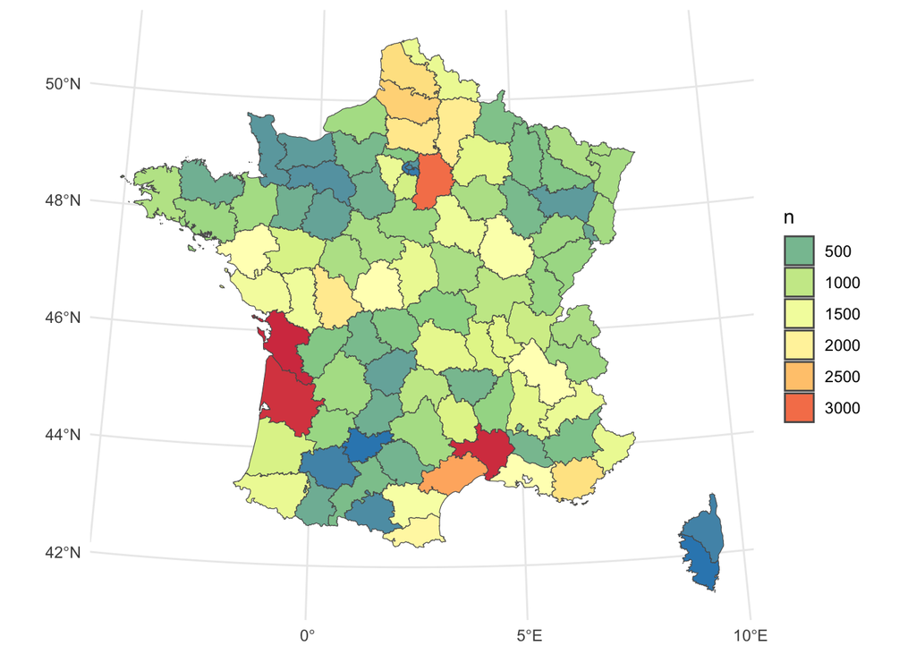

```r
# Question 09
france |>
  inner_join(bird_cnt, by = "departement") |>
  st_transform(27561) |>
  ggplot() +
    geom_sf(aes(fill = n), size = 0) +
    scale_fill_distiller(palette = "Spectral", guide = "legend", n.breaks = 10)
```